# Covid-19 infección en Ecuador. Modelos matemáticos y predicciones

Una comparación de modelos, lineal, polilnomico,logísticos y exponenciales aplicados a la infección por el virus Covid-19

Se crea modelos de series temporales del número total de personas infectadas hasta la fecha (es decir, las personas realmente infectadas más las personas que han sido infectadas). Estos modelos tienen parámetros , que se estimarán por ajuste de curva.

```python
# Importar las librerias para el analasis
import pandas as pd
import numpy as np
import time
import datetime
from sklearn.metrics import mean_squared_error, r2_score
#from sklearn.preprocessing import PolynomialFeatures
from datetime import datetime,timedelta
#from sklearn.metrics import mean_squared_error
from scipy.optimize import curve_fit
from scipy.optimize import fsolve
from sklearn import linear_model
import matplotlib.pyplot as plt
%matplotlib inline
```

```python
# Actualizar los datos (URL)
url = ('https://covid.ourworldindata.org/data/ecdc/total_cases.csv')
df = pd.read_csv(url)
df = df.fillna(0)
df
```

|  | date | World | Afghanistan | Albania | Algeria | Andorra | Angola | Anguilla | Antigua and Barbuda | Argentina | ... | United States | United States Virgin Islands | Uruguay | Uzbekistan | Vatican | Venezuela | Vietnam | Yemen | Zambia | Zimbabwe |
| --- | --- | --- | --- | --- | --- | --- | --- | --- | --- | --- | --- | --- | --- | --- | --- | --- | --- | --- | --- | --- | --- |
| 0 | 2019-12-31 | 27 | 0.0 | 0.0 | 0.0 | 0.0 | 0.0 | 0.0 | 0.0 | 0.0 | ... | 0 | 0.0 | 0.0 | 0.0 | 0.0 | 0.0 | 0.0 | 0.0 | 0.0 | 0.0 |
| 1 | 2020-01-01 | 27 | 0.0 | 0.0 | 0.0 | 0.0 | 0.0 | 0.0 | 0.0 | 0.0 | ... | 0 | 0.0 | 0.0 | 0.0 | 0.0 | 0.0 | 0.0 | 0.0 | 0.0 | 0.0 |
| 2 | 2020-01-02 | 27 | 0.0 | 0.0 | 0.0 | 0.0 | 0.0 | 0.0 | 0.0 | 0.0 | ... | 0 | 0.0 | 0.0 | 0.0 | 0.0 | 0.0 | 0.0 | 0.0 | 0.0 | 0.0 |
| 3 | 2020-01-03 | 44 | 0.0 | 0.0 | 0.0 | 0.0 | 0.0 | 0.0 | 0.0 | 0.0 | ... | 0 | 0.0 | 0.0 | 0.0 | 0.0 | 0.0 | 0.0 | 0.0 | 0.0 | 0.0 |
| 4 | 2020-01-04 | 44 | 0.0 | 0.0 | 0.0 | 0.0 | 0.0 | 0.0 | 0.0 | 0.0 | ... | 0 | 0.0 | 0.0 | 0.0 | 0.0 | 0.0 | 0.0 | 0.0 | 0.0 | 0.0 |
| ... | ... | ... | ... | ... | ... | ... | ... | ... | ... | ... | ... | ... | ... | ... | ... | ... | ... | ... | ... | ... | ... |
| 97 | 2020-04-06 | 1245596 | 299.0 | 361.0 | 1320.0 | 501.0 | 14.0 | 3.0 | 15.0 | 1554.0 | ... | 337635 | 42.0 | 406.0 | 342.0 | 7.0 | 148.0 | 241.0 | 0.0 | 39.0 | 9.0 |
| 98 | 2020-04-07 | 1316986 | 337.0 | 377.0 | 1423.0 | 526.0 | 16.0 | 3.0 | 15.0 | 1628.0 | ... | 368196 | 42.0 | 415.0 | 397.0 | 7.0 | 159.0 | 245.0 | 0.0 | 39.0 | 9.0 |
| 99 | 2020-04-08 | 1391888 | 367.0 | 383.0 | 1468.0 | 545.0 | 17.0 | 3.0 | 15.0 | 1715.0 | ... | 398809 | 45.0 | 424.0 | 504.0 | 7.0 | 166.0 | 251.0 | 0.0 | 39.0 | 10.0 |
| 100 | 2020-04-09 | 1476818 | 423.0 | 400.0 | 1572.0 | 564.0 | 19.0 | 3.0 | 15.0 | 1795.0 | ... | 432132 | 45.0 | 456.0 | 555.0 | 8.0 | 167.0 | 251.0 | 0.0 | 39.0 | 11.0 |
| 101 | 2020-04-10 | 1563857 | 484.0 | 409.0 | 1666.0 | 583.0 | 19.0 | 3.0 | 19.0 | 1894.0 | ... | 466033 | 50.0 | 473.0 | 582.0 | 8.0 | 171.0 | 255.0 | 1.0 | 39.0 | 11.0 |

102 rows × 208 columns

Imprimos los resultados y agregamos el numero del dia

```python
#df = df['date'] #Filtro la Informacion solo para Ecuador
df = df.loc[:,['date','Ecuador']] #Selecciono las columnas de analasis
# Expresar las fechas en numero de dias desde el 01 Enero
FMT = '%Y-%m-%d'
date = df['date']
df['date'] = date.map(lambda x : (datetime.strptime(x, FMT) - datetime.strptime("2019-12-31", FMT)).days)
#df.fillna(0)
df['Ecuador'].astype(int)
df= df[df["Ecuador"] > 0.0]
df
```

|  | date | Ecuador |
| --- | --- | --- |
| 61 | 61 | 1.0 |
| 62 | 62 | 6.0 |
| 63 | 63 | 7.0 |
| 65 | 65 | 10.0 |
| 66 | 66 | 13.0 |
| 69 | 69 | 14.0 |
| 70 | 70 | 15.0 |
| 71 | 71 | 17.0 |
| 74 | 74 | 23.0 |
| 75 | 75 | 28.0 |
| 76 | 76 | 37.0 |
| 77 | 77 | 58.0 |
| 78 | 78 | 111.0 |
| 79 | 79 | 168.0 |
| 80 | 80 | 199.0 |
| 81 | 81 | 426.0 |
| 82 | 82 | 532.0 |
| 83 | 83 | 789.0 |
| 84 | 84 | 981.0 |
| 85 | 85 | 1082.0 |
| 86 | 86 | 1211.0 |
| 87 | 87 | 1403.0 |
| 88 | 88 | 1627.0 |
| 89 | 89 | 1835.0 |
| 90 | 90 | 1890.0 |
| 91 | 91 | 1966.0 |
| 92 | 92 | 2302.0 |
| 93 | 93 | 2758.0 |
| 94 | 94 | 3163.0 |
| 95 | 95 | 3368.0 |
| 96 | 96 | 3465.0 |
| 97 | 97 | 3646.0 |
| 98 | 98 | 3747.0 |
| 99 | 99 | 3995.0 |
| 100 | 100 | 4450.0 |
| 101 | 101 | 4965.0 |

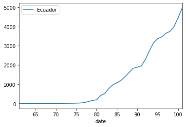

```python
df.plot(x ='date', y='Ecuador')
```

## EL modelo lineal

La regresión lineal es un algoritmo de aprendizaje supervisado que se utiliza en Machine Learning y en estadística. En su versión más sencilla, lo que haremos es «dibujar una recta» que nos indicará la tendencia de un conjunto de datos continuos.

Recordemos rápidamente la fórmula de la recta:

Y = mX + b

Recordemos que los algoritmos de Machine Learning Supervisados, aprenden por sí mismos y -en este caso- a obtener automáticamente esa «recta» que buscamos con la tendencia de predicción. Para hacerlo se mide el error con respecto a los puntos de entrada y el valor «Y» de salida real.

```python
x = list(df.iloc [:, 0]) # Fecha
y = list(df.iloc [:, 1]) # Numero de casos
# Creamos el objeto de Regresión Lineal
regr = linear_model.LinearRegression()

# Entrenamos nuestro modelo
regr.fit(np.array(x).reshape(-1, 1) ,y)

# Veamos los coeficienetes obtenidos, En nuestro caso, serán la Tangente
print('Coefficients: \n', regr.coef_)
# Este es el valor donde corta el eje Y (en X=0)
print('Independent term: \n', regr.intercept_)
# Error Cuadrado Medio
```

```
Coefficients:
 [118.87532371]
Independent term:
 -8432.884407567966
```

De la ecuación de la recta y = mX + b nuestra pendiente «m» es el coeficiente y el término independiente «b»

```python
#Vamos a comprobar:
# Quiero predecir cuántos "Casos" voy a obtener por en el dia 100,
# según nuestro modelo, hacemos:
y_prediccion = regr.predict([[100]])
print(int(y_prediccion))
```

```
3454
```

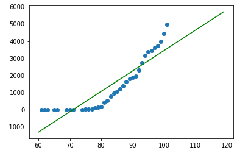

```python
#Graficar
plt.scatter(x, y)
x_real = np.array(range(60, 120))
plt.plot(x_real, regr.predict(x_real.reshape(-1, 1)), color='green')
plt.show()
```

```python
def modelo_logistico(x,a,b):
    return a+b*np.log(x)

exp_fit = curve_fit(modelo_logistico,x,y) #Extraemos los valores de los paramatros
print(exp_fit)
```

```
(array([-39018.80961254,   9175.31091083]), array([[15292889.94943169, -3468042.5575952 ],
       [-3468042.5575952 ,   787316.12858984]]))
```

## Graficas

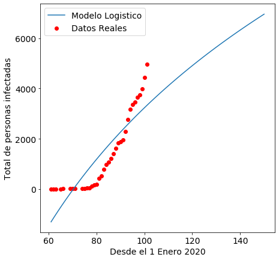

```python
pred_x = list(range(min(x),max(x)+50)) # Predecir 50 dias mas
plt.rcParams['figure.figsize'] = [7, 7]
plt.rc('font', size=14)
# Real data
plt.scatter(x,y,label="Datos Reales",color="red")
# Predicted exponential curve
plt.plot(pred_x, [modelo_logistico(i,exp_fit[0][0],exp_fit[0][1]) for i in pred_x], label="Modelo Logistico" )
plt.legend()
plt.xlabel("Desde el 1 Enero 2020")
plt.ylabel("Total de personas infectadas")
#plt.ylim((min(y),max(y)*3.1)) # Definir los limites de Y
plt.show()
```

## Modelo exponencial

Mientras que el modelo logístico describe un crecimiento de infección que se detendrá en el futuro, el modelo exponencial describe un crecimiento de infección imparable . Por ejemplo, si un paciente infecta a 2 pacientes por día, después de 1 día tendremos 2 infecciones, 4 después de 2 días, 8 después de 3 y así sucesivamente.

A continuacion se tiene un ejemplo de regresion exponencial

```python
# Implementar
def modelo_exponencial(x, a, b,c):
    #return (a*np.exp(b*x-50)
    return a * np.exp(b*(x - c))

popt, pcov = curve_fit(modelo_exponencial, x, y, maxfev=2000)
print(popt)
```

```
[ 1.42377741  0.10074563 19.45705437]
```

```
Modelo de prediccion EXPONENCIAL
Total infectados del dia 101: 5263.0
```

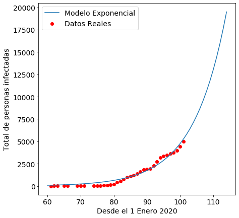

```python
pred_x = np.array(range(60,115)) # Predecir
plt.rcParams['figure.figsize'] = [7, 7]
plt.rc('font', size=14)

plt.scatter(x,y,label="Datos Reales",color="red")
plt.plot(pred_x, [modelo_exponencial(i,popt[0],popt[1],popt[2]) for i in pred_x], label="Modelo Exponencial" )
print("Modelo de prediccion EXPONENCIAL")
print("Total infectados del dia 101:",round(modelo_exponencial(101,popt[0],popt[1],popt[2])))
plt.legend()
plt.xlabel("Desde el 1 Enero 2020")
plt.ylabel("Total de personas infectadas")
plt.show()
print()
```

## Modelo polinomial

Predicción de una variable de respuesta cuantitativa a partir de una variable predictora cuantitativa, donde la relación se modela como una función polinomial de orden n (esto significa que pueden tener de diferentes exponenciales o grados y se debe ir probando)

Se puede tener una ecuacion con diferentes grados

y = a0 + a1x + a2x^2 + a3x^3 + … + anx^n + ε

Ejemplo de una regresion polinomica de grado 4.

```
Preddicion POLINOMIAL con un grado de: 4
Total de infectados en el dia 101: 4722.0

Preddicion POLINOMIAL con un grado de: 5
Total de infectados en el dia 101: 4788.0
```

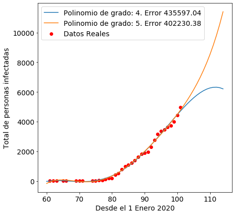

```python
# Implementar
modelo_polinomial = {}
prediccion = 0

for grado in range(4,6):
    resultados_modelo = np.polyfit(x, y, grado, full=True)
    modelo_polinomial[grado] = resultados_modelo

plt.rcParams['figure.figsize'] = [7, 7]
plt.rc('font', size=14)
plt.scatter(x,y,label="Datos Reales",color="red")

prediccion_x = np.array(range(60,115))
for grado, modelo in modelo_polinomial.items():
    coeficientes, error, *_ = modelo
    prediccion = np.poly1d(coeficientes)
    print("Preddicion POLINOMIAL con un grado de:",grado)
    print("Total de infectados en el dia 101:",round(prediccion(101)))
    print()
    plt.plot(prediccion_x, prediccion(prediccion_x), "-", label="Polinomio de grado: %s. Error %.2f" % (grado, error) )
plt.legend()
plt.xlabel("Desde el 1 Enero 2020")
plt.ylabel("Total de personas infectadas")
plt.show()
```

## Analisis

- De todas las librerías que se hicieron uso en este proyecto, algunas de ellas fueron de mucha utilidad como es la librería PANDAS que ayuda de forma rápida y sencilla a leer un archivo y mostrar, filtrar y rellenar campos del mismo en caso de ser necesario.
- Otra librería que ayudó a la resolución de estos ejercicios es la librería NUMPY, con la cual se llamo a una de sus clases que permite realizar el método polinomial de forma rápida, al igual que en el caso del modelo exponencial y la librería se encarga de encontrar los coeficientes.

## Criterio personal (politico, economico y social de la situacion)

- Político, creo que esto afecta mucho a este ámbito ya que dependerá mucho de las decisiones que estos personajes tomen para que la situación del país mejore en las próximas semanas, como se a visto Ecuador actualmente no esta en la mejor posición por la medidas que se han tomado.
- Económico, es evidente una crisis ya que hay muchos trabajos que se han detenido indefinidamente por lo que muchos hogares no estan generando comoantes los recursos necesarios y a más con las medidas que se han tomado últimamente en el país, el nivel de desempleo ha aumentado y muchas empresas han reportado perdidas por la crisis actual a nivel no solo del país si no que a nivel del mundo.
- Social, la mayoría de la población no toma en serio que este virus es una pandemia y debe acatar las disposiciones de cada gobierno, el distanciamiento social es muy evidente en diferentes paises pero no todos entienden la gravedad del asunto por así decirlo, en el país las cifras demuestran que en la provincia de Guayaquil donde se reportan la mayoría de los casos a pesar de las medidas que han sido dispuestas por las autoridades para tratar de controlar la expansión del virus, aún existe mucha gente que no esta dispuesta a acatarlas, ya sea por el hecho de que necesitan laborar o simplemente por curiosidad se aglomeran y crean un ambiente "peligroso" para los demás ciudadanos. Personalmente pienso que nos falta como país aprender mucho mas a respetar a nuestros compatriotas, nos falta saber acatar las medidas de prevensión y tomar las cosas con la seriendad que se merecen.

# Referencias

- https://www.researchgate.net/publication/340092755_Infeccion_del_Covid-19_en_Colombia_Una_comparacion_de_modelos_logisticos_y_exponenciales_aplicados_a_la_infeccion_por_el_virus_en_Colombia
- https://www.aprendemachinelearning.com/regresion-lineal-en-espanol-con-python/